# R Markdown Introduction

Damian Pavlyshyn

4/22/2020

# Compiling the document

The text that you edit directly in RStudio is an RMarkdown document, which is denoted by the `.rmd` file extension. On its own, this is a simple plain text file with no formatting and no capacity to execute code.

To create an attractive document from this `.rmd` file, we need to “compile” or “knit” it by pressing the “Knit” button in the RStudio interface. This passes the `.rmd` file as input to the “knitr” program, which runs all of the R code in the document and uses that output together with the text and formatting instructions contained in the `.rmd` file to create an `.html` or `.pdf` file (or many other file types if you so choose).

# The components of an R Markdown file

Each R Markdown file consists of three parts

1. **The YAML header:** The bit at the top. This contains meta-data about the document, such as the title, author, date and specification of the type of output file that you want. This doesn’t appear in the output file.
2. **Text:** Plain text together with Markdown formatting instructions. This is formatted by knitr and included as-is in the output document.
3. **Code chunks:** R code that is run while the document is compiled. Both the code and the resulting output is displayed in the output document.

## Code chunks

These sections of R code are separated from the rest of the document by triple back-quotes (*note:* this is the symbol in the top-left of your keyboard on the same key as the tilde). The opening back-quotes must be followed by `{r <name>}`, where `<name>` a name that you choose for each chunk,

When you’re writing chunks, you can run them in exactly the same way as when you run code in the script editor. The output of the chunk is then displayed underneath it for your convenience.

```r
v <- c(-1, 2, 4, 0)
mean(v)
```

```
## [1] 1.25
```

When we compile the R Markdown document, the output will include nicely formatted versions of the input and the output, which is super useful for letting people know *exactly* what you’re doing at each set of an analysis.

All chunks share an environment, so variables from previous chunks carry over to subsequent ones:

```r
v[1]
```

```
## [1] -1
```

We can also include plots in RMarkdown chunks:

```r
library(tidyverse)
```

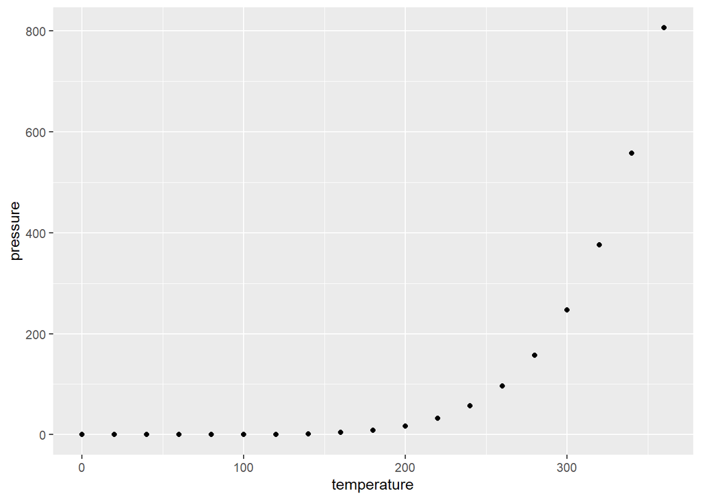

```r
ggplot(pressure, aes(x = temperature, y = pressure)) +
  geom_point()
```

## Text and Markdown formatting

Markdown is a specification for formatting text which is reasonably flexible which still being able to be represented in plain text.

Notice that paragraph breaks are indicated by a blank line - text started on a new line immediately below another block of text will **not** start a new paragraph. It’s generally good practice to have each sentence on its own line, but don’t worry too much about this.

### Sections and subsections

Well-structured documents are divided into sections and sub-sections (but don’t go crazy on subsection hierarchy).

New sections are begun with headings. A heading is denoted in Markdown with some number of # symbols — the more #s, the deeper in the section hierarchy and the smaller the heading.

### Text formatting

We can format the appearance of text using Markdown commands; in fact, we’ve seen several examples of this already. We can make text *italic*, **bold**, <sup>superscripted</sup> or in a `typewriter` font.

We can also include hyperlinks http://web.stanford.edu/class/stats32/ directly, as well as [named links](http://web.stanford.edu/class/stats32/).

External images are included using a similar syntax:

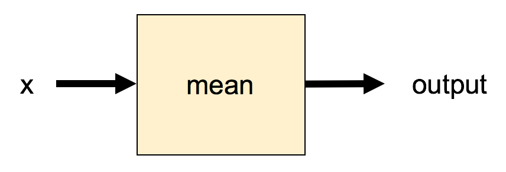

### Lists

RMarkdown can make bulleted lists by starting lines with asterisks:

- A first item
- Another item
  - A subitem denoted with *exactly* four spaces before its plus

Similarly, we can make numbered lists:

1. Fist item
2. Second item
   - Item 2a
3. A third item

In fact, we don’t even have to number the items properly

1. This is the first item
2. Though the source numbering is still 1, this is the second item
3. Still counting up…

# The header

The header included in this document is enough for most basic purposes. Headers tend to contain more detailed document-wide formatting information, some of which are addressed in the advanced R Markdown example document.